# Лабораторная работа №6

Установка и настройка системы управления базами данных MariaDB

Устинова В. В.

Российский университет дружбы народов, Москва, Россия

03 октября 2026

# Информация

## Докладчик

- Устинова Виктория Вадимовна
- студент НПИбд-01-24
- Российский университет дружбы народов

## Цель работы

Приобретение практических навыков по установке и конфигурированию системы управления базами данных на примере программного обеспечения MariaDB.

## Задание

1. Установите необходимые для работы MariaDB пакеты (см. раздел 6.4.1).
2. Настройте в качестве кодировки символов по умолчанию utf8 в базах данных.
3. В базе данных MariaDB создайте тестовую базу addressbook, содержащую таблицу city с полями name и city, т.е., например, для некоторого сотрудника указан город, в котором он работает (см. раздел 6.4.1).
4. Создайте резервную копию базы данных addressbook и восстановите из неё данные (см. раздел 6.4.1).
5. Напишите скрипт для Vagrant, фиксирующий действия по установке и настройке базы данных MariaDB во внутреннем окружении виртуальной машины server. Соответствующим образом следует внести изменения в Vagrantfile (см. раздел 6.4.5).

## Выполнение лабораторной работыПросмотр конфигурационных файлов MariaDB.

Просмотрите конфигурационные файлы mariadb в каталоге /etc/my.cnf.d и в файле /etc/my.cnf. В отчёте прокомментируйте построчно их содержание

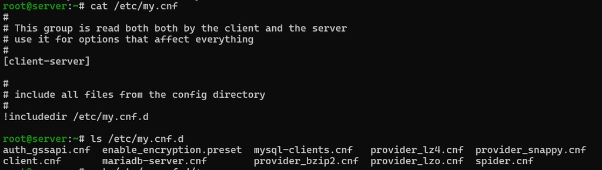

В /etc/my.cnf указаны группы [client-server] и директива !includedir /etc/my.cnf.d. В каталоге /etc/my.cnf.d находятся файлы: auth_gssapi.cnf, client.cnf, enable_encryption.preset, mariadb-server.cnf, mysql-clients.cnf, provider_bzip2.cnf, provider_lz4.cnf, provider_lzo.cnf, provider_snappy.cnf, spider.cnf.

## Содержимое каталога my.cnf.d.

Просмотреть содержание конфигурационных файлов MariaDB в каталоге /etc/my.cnf.d и прокомментировать их.

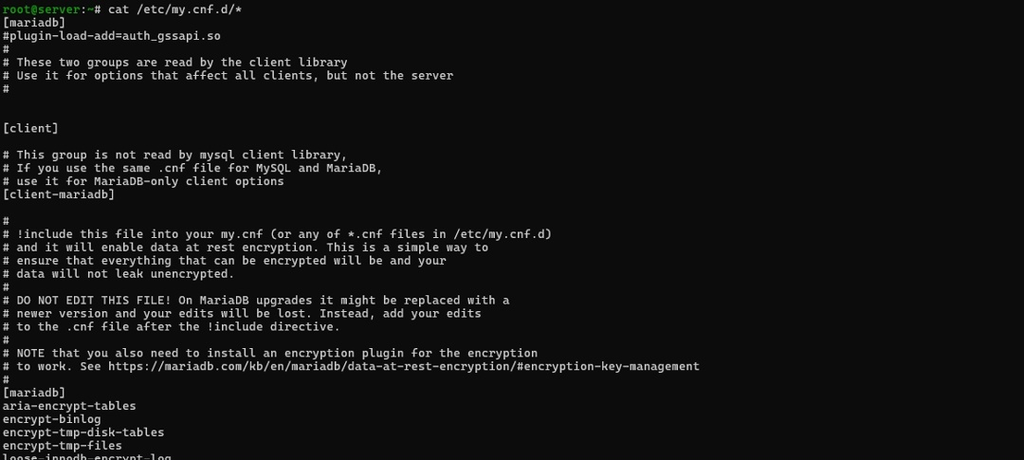

В файлах указаны группы [client], [client-mariadb], [mariadb], директивы шифрования данных (aria-encrypt-tables, encrypt-binlog, encrypt-tmp-disk-tables).

## Запуск и включение mariadb.

Запустить и включить программное обеспечение mariadb командами systemctl start mariadb и systemctl enable mariadb, убедиться, что mariadb прослушивает порт.

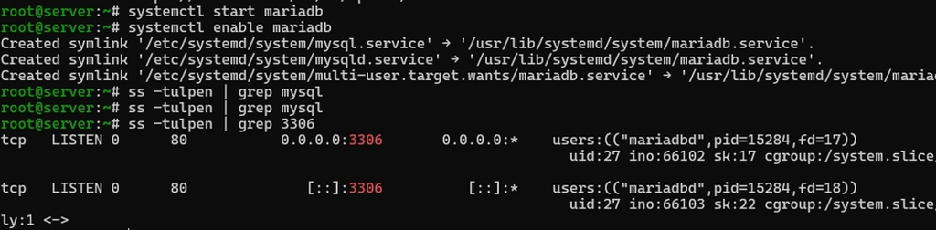

## Настройка безопасности mariadb.

Запустить скрипт конфигурации безопасности mariadb командой mysql_secure_installation, установить пароль для пользователя root базы данных, отключить удалённый корневой доступ и удалить тестовую базу данных.

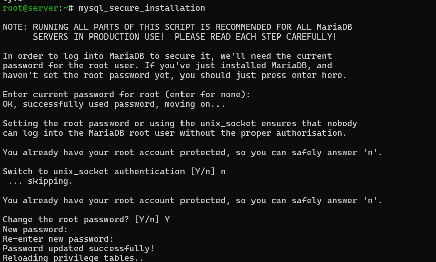

В диалоге установлен пароль root, отключён удалённый корневой доступ, удалена тестовая база данных и анонимные пользователи, обновлены привилегии.

## Вход в MariaDB и список команд.

Войти в базу данных с правами администратора командой.

[figure not shown]

В интерактивной оболочке MariaDB выведен список клиентских команд: charset, clear, connect, delimiter, edit, ego, exit.

## Просмотр доступных баз данных.

Из приглашения интерактивной оболочки MariaDB отобразить доступные в настоящее время базы данных запросом SHOW DATABASES

[figure not shown]

Выведены базы данных: information_schema, mysql, performance_schema, sys.

## Статус MariaDB до настройки кодировки.

Для отображения статуса MariaDB ввести из приглашения интерактивной оболочки команду status и построчно пояснить выведенную информацию.

[figure not shown]

Показаны Connection id, Current user root@localhost, Server version 10.11.18-MariaDB, Connection Localhost via UNIX socket, Server characterset latin1, Db characterset latin1.

## Создание файла utf8.cnf.

В каталоге /etc/my.cnf.d создать файл utf8.cnf и указать в нём конфигурацию для кодировки utf8.

[figure not shown]

В файле прописаны секции [client] с default-character-set = utf8 и [mysqld] с character-set-server = utf8.

## Статус MariaDB после настройки кодировки.

Перезапустить MariaDB, войти в базу данных с правами администратора и посмотреть статус MariaDB, пояснить, что изменилось

[figure not shown]

В статусе изменились Server characterset, Db characterset, Client characterset и Conn. characterset на utf8mb3. Connection id 3, Uptime 34 sec.

## Создание базы данных addressbook.

Создать базу данных с именем addressbook командой CREATE DATABASE addressbook CHARACTER SET utf8 COLLATE utf8_general_ci и перейти к ней командой USE addressbook.

[figure not shown]

База данных создана, выполнено переключение на addressbook, команда SHOW TABLES показывает пустой набор.

## Создание таблицы city и заполнение данными.

Создать таблицу city с полями name и city, заполнить несколько строк данными (Иванов, Москва; Петров, Сочи; Сидоров, Дубна) и выполнить запрос SELECT * FROM city.

[figure not shown]

Таблица создана, добавлены 3 строки, запрос SELECT выводит все записи таблицы.

## Создание пользователя и привилегий.

Создать пользователя для работы с базой данных addressbook, задать пароль, предоставить права на действия с базой и посмотреть общую информацию о таблице city

[figure not shown]

Выполнены CREATE USER vvustinova@‘%’, GRANT SELECT,NSERT, UPDATE, DELETE ON addressbook.*, FLUSH PRIVILEGES. Команда DESCRIBE city показывает поля name и city типа varchar(40)

## Просмотр баз и таблиц через mysqlshow

Выйти из окружения MariaDB, просмотреть список баз данных командой mysqlshow -u root -p и список таблиц базы данных addressbook

[figure not shown]

Выведены базы данных: addressbook, information_schema, mysql, performance_schema, sys. В базе addressbook присутствует таблица city.

## Резервное копирование базы данных.

Создать каталог для резервных копий, сделать резервную копию базы данных addressbook, сжатую резервную копию и сжатую копию с указанием даты

[figure not shown]

Выполнены команды mysqldump с созданием файлов addressbook.sql, addressbook.sql.gz и addressbook.20261003.100018.sql.gz в каталоге /var/backup.

## Восстановление из резервной копии.

Восстановить базу данных addressbook из резервной копии и из сжатой резервной копии

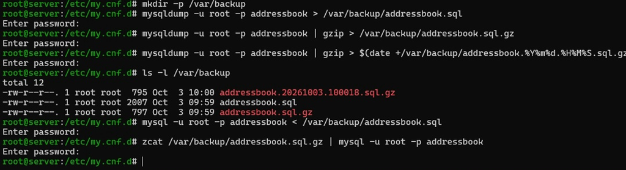

Выполнены команды mysql -u root -p addressbook < /var/backup/addressbook.sql и zcat /var/backup/addressbook.sql.gz | mysql -u root -p addressbook.

## Копирование конфигурационных файлов MySQL.

На виртуальной машине server перейти в каталог /vagrant/provision/server, создать каталог mysql и скопировать в него конфигурационные файлы MariaDB и резервную копию базы данныx

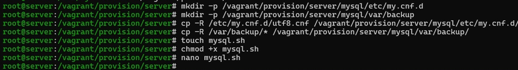

Созданы каталоги mysql/etc/my.cnf.d и mysql/var/backup, скопированы utf8.cnf и файлы резервных копий, создан исполняемый файл mysql.sh.

## Скрипт mysql.sh.

В каталоге /vagrant/provision/server создать исполняемый файл mysql.sh, который повторяет действия по установке и настройке сервера баз данных

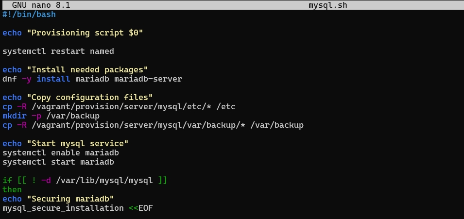

В скрипте прописаны перезапуск named, установка mariadb и mariadb-server, копирование конфигураций, запуск службы, безопасная установка и создание базы данных.

## Подключение provision в Vagrantfile.

Для отработки созданного скрипта во время загрузки виртуальных машин добавить в конфигурационном файле Vagrantfile в конфигурации сервера запись provision «server mysql».

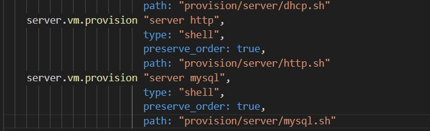

В Vagrantfile добавлены provision server dns, server dhcp, server http и server mysql с путями к соответствующим скриптам.

## Выводы

В ходе работы были приобретены практические навыки по установке и конфигурированию системы управления базами данных MariaDB. Освоены установка пакетов, настройка безопасности, изменение кодировки символов на utf8, создание базы данных addressbook и таблицы city, работа с пользователями и привилегиями. Выполнено резервное копирование и восстановление базы данных. Создан скрипт автоматической установки и настройки MariaDB для Vagrant.

## Библиографический список

1. MariaDB Foundation. — URL: https://mariadb.org
2. Документация по MariaDB. — URL: https://mariadb.com/kb/ru/5306/
3. Основы языка SQL. — URL: http://citforum.ru/programming/321less/les44.shtml
4. MariaDB Documentation. Backing Up and Restoring. — URL: https://mariadb.com/kb/en/backup-and-restore-overview/
5. Red Hat Enterprise Linux 10. Configuring MariaDB. — URL: https://docs.redhat.com/en/documentation/red_hat_enterprise_linux/10/html/configuring_and_using_database_servers/